# Analysis of pedestrian collision for the city of Toronto

Kar Hian Ong

2020-09-22

Kar Hian Ong

# Abstract

Pedestrian is part and parcel of life in a city. In this paper, we explore the transportation data for the years 2008 and 2011 which is an observational dataset. We find that there exists some correlation between pedestrian collision and TTC stops. Our findings have implications for forecasting pedestrian collision prone areas and the factors that may cause it.

# Introduction

With health being the talk of the world, something that is not being talked enough is pedestrian safety. Even with road safety initiatives, pedestrians have been injured by cars. There are also instances of pedestrians being killed$(^6)$ in the streets of Toronto. Being a pedestrian myself I wonder how safe is the streets of Toronto. With that being said, take a moment to think about the city you live in. Is it a pedestrian-friendly city? If not, what can be improved in the city you live in? This is what I set to find for the city of Toronto.

Finally, this paper outline several figures to better visualize the data. With this paper, I would like to advocate for safer streets. This is so that if the city officials read my paper, they might consider making the city safer for pedestrians, and if drivers read my paper, they would slow down and be more aware of any pedestrians that are near a crosswalk. Through my analysis, I have found that there is a general decrease in the number of collisions involving a pedestrian from 2008 to 2011.

# Data

I have obtained a dataset from Open Data Toronto (Gelfand (2020)). This dataset consists of transportation data from 140 neighbourhoods in Toronto for the years 2008 and 2011. Below is an overview of the 2008 dataset. The data set is broken into 2 sheets one for 2008 and the other for 2011. 2011 datasets contain the same variables as in 2008.

```r
head(data_2008)
```

```
## # A tibble: 6 x 8
##   Neighbourhood `Neighbourhood ~ `TTC Stops` `TTC Overcrowde~ `Pedestrian/Oth~
##   <chr>                    <dbl>       <dbl>            <dbl>            <dbl>
## 1 West Humber-~                1         326             1782              961
## 2 Mount Olive-~                2          67              212              283
## 3 Thistletown-~                3          45              159              143
## 4 Rexdale-Kipl~                4          36              177               79
## 5 Elms-Old Rex~                5          29              165               77
## 6 Kingsview Vi~                6          52              260              141
## # ... with 3 more variables: `Traffic Collisions` <dbl>, `Road
## #   Kilometres` <dbl>, `Road Volume` <dbl>
```

The variables that we will focus on are pedestrian/other collisions and TTC stops. Based on the description provided by the dataset, pedestrian/other Collisions includes pedestrians, cyclists and private property collisions and TTC stops include all bus, streetcar and non-subway stops, counted by neighbourhood.

Here is a summary statistics for the variable of interest.

```r
summary(data_2008$`Pedestrian/Other Collisions`)
```

```
##    Min. 1st Qu.  Median    Mean 3rd Qu.    Max.
##   20.00   79.75  148.00  213.53  246.50 1085.00
```

```r
summary(data_2011$`Pedestrian/Other Collisions`)
```

```
##    Min. 1st Qu.  Median    Mean 3rd Qu.    Max.
##    20.0    66.0   114.5   174.6   208.2  1007.0
```

```r
summary(data_2008$`TTC Stops`)
```

```
##    Min. 1st Qu.  Median    Mean 3rd Qu.    Max.
##   15.00   35.00   51.50   65.91   79.50  326.00
```

```r
summary(data_2011$`TTC Stops`)
```

```
##    Min. 1st Qu.  Median    Mean 3rd Qu.    Max.
##   11.00   40.00   58.50   71.21   90.00  338.00
```

The average number of TTC stops has increased and the average number of pedestrian collisions has decreased.

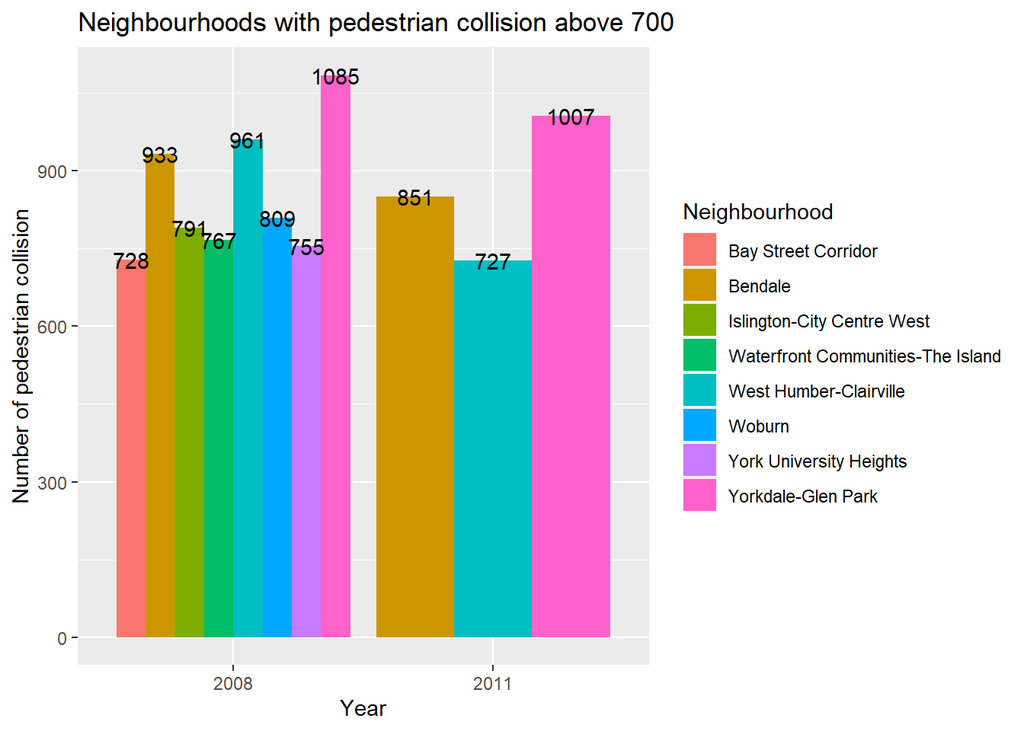

Neighbourhoods with pedestrian collisions above 700 for 2008 and 2011

The number of neighbourhoods with pedestrian collisions above 700 has decreased.

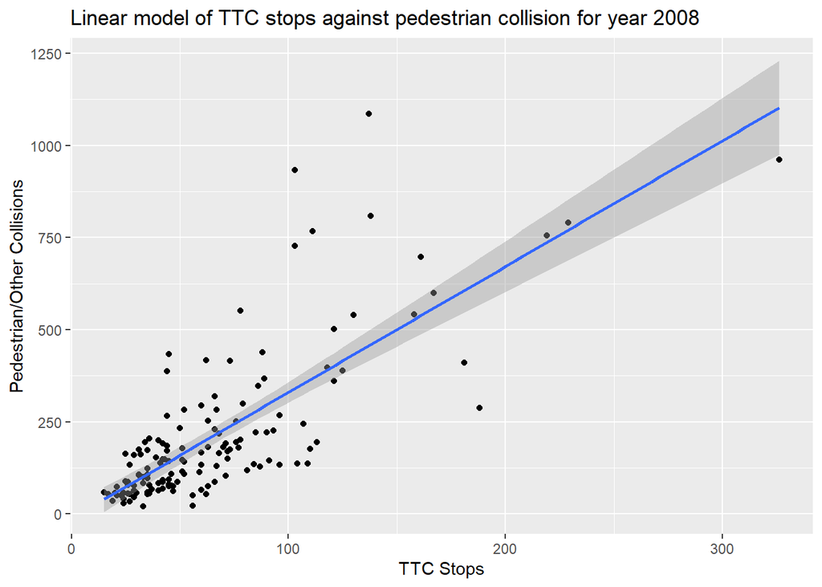

```r
data_2008 %>%
  ggplot(aes(x= `TTC Stops`,y= `Pedestrian/Other Collisions`))+geom_point()+ geom_smooth(method='lm')+ggtitle("Linear model of TTC stops against pedestrian collision for year 2008")
## `geom_smooth()` using formula 'y ~ x'
```

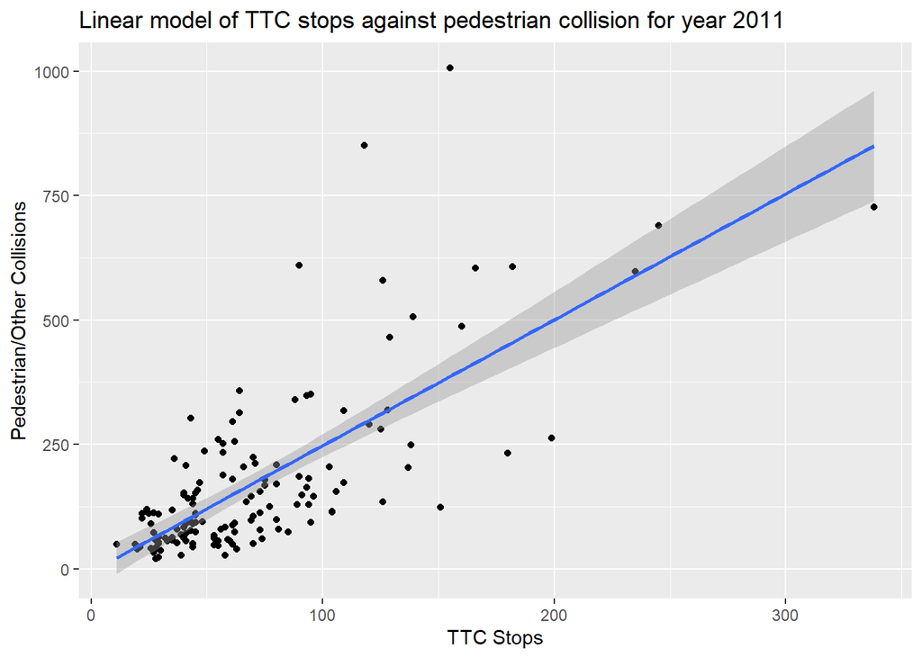

```r
data_2011%>%
ggplot(aes(x= `TTC Stops`,y= `Pedestrian/Other Collisions`))+geom_point()+ geom_smooth(method='lm')+ggtitle("Linear model of TTC stops against pedestrian collision for year 2011")
## `geom_smooth()` using formula 'y ~ x'
```

Both graphs shows a positive correlation between TTC Stops and Pedestrian Collision.

# Disccussion

## Weaknesses

Due to the data being sourced from Open Data Toronto, I have no control over what is being collected. There may be cases of under-reporting. There is some information that might be useful for my analysis is not present. They are the population density of a neighbourhood, the cause of the collision, and if that incident caused a loss of life. As the pedestrian data is grouped into pedestrians, cyclists, and private property collisions, I am unable to filter into the data for pedestrians only. My weaknesses are that there is no full regression analysis done on the plots. Besides that, the data provided is only for the years 2008 and 2011, a clearer picture can be obtained if I have the data for all the years from 2008 to 2020.

# References

1. Wickham et al. (2019)
2. Xie (2020)
3. Allaire et al. (2020)
4. Gelfand (2020)
5. Dataset from https://open.toronto.ca/dataset/wellbeing-toronto-transportation/
6. News reports of pedestrian killed https://www.youtube.com/watch?v=dqHH-J85Fe4 and https://www.theglobeandmail.com/canada/toronto/article-man-killed-in-hit-and-run-saturday-night-in-toronto-marking-citys/
7. R Core Team (2020)
8. RStudio Team (2019)

Allaire, JJ, Yihui Xie, Jonathan McPherson, Javier Luraschi, Kevin Ushey, Aron Atkins, Hadley Wickham, Joe Cheng, Winston Chang, and Richard Iannone. 2020. *Rmarkdown: Dynamic Documents for R*. https://github.com/rstudio/rmarkdown.

Gelfand, Sharla. 2020. *Opendatatoronto: Access the City of Toronto Open Data Portal*. https://CRAN.R-project.org/package=opendatatoronto.

R Core Team. 2020. *R: A Language and Environment for Statistical Computing*. Vienna, Austria: R Foundation for Statistical Computing. https://www.R-project.org/.

RStudio Team. 2019. *RStudio: Integrated Development Environment for R*. Boston, MA: RStudio, Inc. http://www.rstudio.com/.

Wickham, Hadley, Mara Averick, Jennifer Bryan, Winston Chang, Lucy D’Agostino McGowan, Romain François, Garrett Grolemund, et al. 2019. “Welcome to the tidyverse.” *Journal of Open Source Software* 4 (43): 1686. https://doi.org/10.21105/joss.01686.

Xie, Yihui. 2020. *Blogdown: Create Blogs and Websites with R Markdown*. https://github.com/rstudio/blogdown.